# Evaluation des performances de Sofa-Flexible

Tout d'abord un petit script R pour lire les fichiers d'expérience et créer les courbes (je peux mettre les logs a disposition, à la demande). Cette partie du code n'est pas très intéressante sauf si vous voulez voir ce qui se passe quand on débute en R …

```r
require(methods)
require(ggplot2)
MyPlotter<-function(datas, Metric=NULL, Title=NULL)
{
    #Todo: Commenter
    if( length(datas$Config)>2 )
    {
        p <-ggplot(datas,aes(x=Region,y=mean,fill=Config, group=Config))
        #p <- p + geom_errorbar(aes(ymin=mean-se,ymax=mean+se, width=.2,
        #                           position="dodge"))
        p <- p + scale_fill_discrete(name="Runtime",
                         labels=c("Openmp", "Sequential"))
        p <- p + theme(legend.position="bottom",
                   axis.text.y=element_text(size=12, colour="#000000"))
    }
    else
    {
        p <-ggplot(datas,aes(x=Config,y=mean,fill=Config))
        p <- p + geom_errorbar(aes(ymin=mean-se,ymax=mean+se,width=.2))
        p <- p + theme(legend.position="none",
                       axis.text.y=element_text(size=12, colour="#000000"))
        p <- p + scale_x_discrete(labels=c("Openmp", "Sequential"))
    }
    p <- p + geom_bar(stat="identity", position="dodge")
    p <- p + coord_flip()
    p <- p + ylab(Metric)
    p <- p + xlab(Title)
    #ggsave(file=paste(basedir,"/figure/",Title,".png",sep=""))
    return(p)
}
# This script must be run from the root directory of the experiment output
# The experiment output files are organised in a tree similar to the
# following:
# Scene 1
#   . Group (likwid) 1
#   .   Config (seq, openmp, seq-perfmon ...) 1
#   .     run1.Metric1.csv
#   .     run2.Metric1.csv
#   .     run1.Metric2.csv
#   .       .
#   .   Config 2
#   .     .
#   .   .
#   . Group 2
#   . .
# Scene 2
library(ggplot2)
library(plyr)
#library(reshape2)
#palete for colorblind from
#http://www.cookbook-r.com/Graphs/Colors_(ggplot2)/#a-colorblind-friendly-palette
# The palette with grey:
# TODO: Use cbPalette
#cbPalette <- c("#999999", "#E69F00", "#56B4E9", "#009E73", "#F0E442",
#"#0072B2", "#D55E00", "#CC79A7")

basedir<-getwd()

#Initialize an empty plot list in 3D
plots<-list(c())
plotTitles<-list(c())
groupNames<-c()
nplots<-0
scnNum<-1
setwd(basedir)
#
#parse all results by scenes, groups (likwid sets), config (seq, openmp etc.)
#and create one plot by config
#
for (scndir in dir(pattern=".*.scn", path=basedir, no..=T,full.names=T))
{
    plots[[scnNum]]<-list(c())
    plotTitles[[scnNum]]<-list(c())
    setwd(scndir)
    #show(scndir)
    grpNum<-1
    for (grpdir in dir(path=scndir, no..=T,full.names=T))
    {
        plots[[scnNum]][[grpNum]]<-list(c())
        plotTitles[[scnNum]][[grpNum]]<-list(c())
        if(!file.info(grpdir)$isdir)
        {
            next
        }
        setwd(grpdir)
        #show(grpdir)
        if (scnNum == 1)
        {
            groupNames<-c(groupNames,basename(grpdir))
        }
        results <- NULL;
        ndir <-0
        for (dir in dir(path=grpdir, no..=T,full.names=T))
        {
            if(!file.info(dir)$isdir)
            {
                next
            }
            #show(dir)
            nrun<-0
            setwd(dir)
            for(file in list.files(path=dir, pattern="run.*.Metric.csv"))
            {
                #read the csv file
                curdata<-data.frame(read.csv(file,sep=",",
                                            quote="\"",dec=".", header=T,
                                            stringsAsFactors=F,as.is=T))
                expe<-basename(dir)

                if(NCOL(curdata) > 4)
                {
                    tmp<-(curdata[,1:3])
                    # For most metric, the average between the cores is the
                    # interesting one
                    tmp$Value<-curdata$Avg
                    # However for the metric matched by the following grep,
                    # we are interested by the sum amoung the processors
                    resgrep<-grep("Simulation time|Througput|Memory|bandwidth|data volume",
                                  curdata$Metric)
                    tmp$Value[resgrep]<-curdata$Sum[resgrep]
                    resgrep<-grep("miss ratio | request rate | CPI|Runtime",curdata$Metric)
                    tmp$Value[resgrep]<-curdata$Max[resgrep]
                    curdata<-tmp
                    remove(tmp)
                }
                curdata$runId<-nrun;
                colnames(curdata)<-c("Config","Region" ,"Metric","Value", "runId")
                if(grpNum > 1)
                {
                    #All the following metrics are interesting only once per scene
                    #Hence we remove them from all groups execpt the first
                    curdata<-curdata[-grep('Runtime|CPI|Clock|Execution time|FPS',curdata$Metric),]
                }
                else
                {
                    #Compute the idle time ratio
                    resgrep <- grep("unhalted", curdata$Metric)
                    resgrep1 <- grep("RDTSC", curdata$Metric)
                    for( i in 1:NROW(resgrep))
                    {
                        val  <-  100*(1-as.numeric(curdata$Value[resgrep[i]])/
                                      as.numeric(curdata$Value[resgrep1[i]]))
                        curdata <- rbind(curdata,
                                       c(curdata$Config[resgrep[i]],curdata$Region[resgrep[i]],"Idle time ratio [%]",val ,nrun))
                    }
                    #Change the Load to store ratio into Store to Load ratio
                    #Not used in the presentation : not very interesting
                    resgrep <- grep("Load to Store ratio",curdata$Metric)
                    for(i in 1:NROW(resgrep))
                    {
                        curdata$Value[resgrep[i]]<-
                            1/as.numeric(curdata$Value[resgrep[i]])
                        curdata$Metric[resgrep[i]]<- "Store to Load ratio"

                    }

                }
                #Because for R integer and numeric are two different things ...
                curdata$Value <- as.numeric(curdata$Value)
                results<-rbind(results,curdata)

                nrun<-nrun+1

                remove(curdata)
            }
            setwd("..")
        }
        remove(dir)
        remove(file)
        remove(expe)
        remove(ndir)
        remove(nrun)

            #Add statisticall stuffs
            stat<-ddply(results,c("Config", "Region", "Metric"),summarise,
                        N=length(Value),mean=mean(Value),sd=sd(Value),se=sd/sqrt(N))
        if(grpNum==1)
        {

            rdtsc <- grep("RDTSC", stat$Metric)
            rdtscRes<-stat[rdtsc,]
            #Reduce to the openmp-perfmon lines
            openmpperfrdtsc<- grep("openmp-perfmon",rdtscRes$Config)
            omprdtscRes<-rdtscRes[openmpperfrdtsc,]
            #Same for seq-perfmon
            seqperfrdtsc<- grep("seq-perfmon",rdtscRes$Config)
            seqrdtscRes<-rdtscRes[seqperfrdtsc,]
            #Compute the sum
            rdtscSimu <- rdtscRes[rdtscRes$Region=="Simu",]
            TotOmpRuntime<-rdtscSimu[rdtscSimu$Config=="openmp-perfmon",]$mean
            TotSeqRuntime<-rdtscSimu[rdtscSimu$Config=="seq-perfmon",]$mean

            for(i in 1:NROW(omprdtscRes))
            {
                #Insert the Runrime ratio Row for omp runs
                val<-100*as.numeric(omprdtscRes[i,]$mean)/TotOmpRuntime
                myline<- c(omprdtscRes[i,]$Config,omprdtscRes[i,]$Region, "Runtime ratio [%]",omprdtscRes[i,]$N,val,0,0)
                stat <- rbind(stat,myline)

            }
            for(i in 1:NROW(seqrdtscRes))
            {
                #The same for seq runs
                val<-100*as.numeric(seqrdtscRes[i,]$mean)/TotSeqRuntime
                myline<- c(seqrdtscRes[i,]$Config,seqrdtscRes[i,]$Region, "Runtime ratio [%]", seqrdtscRes[i,]$N,val,0,0)
                stat <- rbind(stat,myline)

            }
            stat$N<-as.numeric(stat$N)
            stat$mean<-as.numeric(stat$mean)
            stat$se<-as.numeric(stat$se)
            stat$sd<-as.numeric(stat$sd)
            #show(stat)

            remove(rdtsc)
            remove(rdtscRes)
            remove(openmpperfrdtsc)
            remove(omprdtscRes)
            remove(TotOmpRuntime)
            remove(seqperfrdtsc)
            remove(seqrdtscRes)
            remove(TotSeqRuntime)
            remove(myline)
        }

        remove(results)

        #create the plots
        met<-unique(stat$Metric)

        for(mtr in 1:NROW(met))
        {

            plots[[scnNum]][[grpNum]][[mtr]]<-list(c())
            #Create two plots one for experiments on full code, on for experiments
            #  on part of the code
            set<-subset(stat,Metric==unique(stat$Metric)[mtr])
            resgrep<-grep("Full", set$Region)
            #TODO: some code simplification / factorization should be done here
            #If the first grep is false, we can't use -resgrep, so we use a
            #second grep which is a negation of the first. this is a dirty fix
            resgrep1<-grep("Full", set$Region, invert=T)
            miniset <- set[resgrep1,]
            resgrep2 <- grep("Simu", miniset$Region, invert=T)
            resgrep3 <- grep("Simu", miniset$Region)
            nplots<-nplots+1
            #Create the plot, 3 different groups : Full, perfmon Simu, perfmon
            #function some metrics are not available for each groups
            if(NROW(set[resgrep,]) > 0)
            {
                plots[[scnNum]][[grpNum]][[mtr]][[1]]<-MyPlotter(set[resgrep,],
                                        Metric=met[mtr],Title=basename(scndir))
            }
            if(NROW(set[resgrep2,]) > 0 )
            {
                plots[[scnNum]][[grpNum]][[mtr]][[2]]<-MyPlotter(miniset[resgrep2,],
                                        Metric=met[mtr],Title=basename(scndir))
            }
            if(NROW(set[resgrep3,]) > 0 )
            {
                plots[[scnNum]][[grpNum]][[mtr]][[3]]<-MyPlotter(miniset[resgrep3,],
                                        Metric=met[mtr],Title=basename(scndir))
            }
            plotTitles[[scnNum]][[grpNum]][[mtr]]<-met[mtr]
        }
        #show(plotTitles)
        remove(mtr)
        remove(met)
        remove(set)
        remove(miniset)
        remove(stat)
        setwd("..")
        grpNum<-grpNum+1
    }
    remove(grpdir)
    setwd("..")
    scnNum<-scnNum+1
}
remove(scndir)
#remove(cbPalette)
remove(basedir)
remove(resgrep2)
remove(resgrep3)
```

Nous avons utilisé la librairie likwid pour relever les compteurs de performances (hardware) et les grouper par catégorie. Cette analyse focalise sur l'utilisation de la mémoire.

## Metriques indépendantes des groupes likwid

Pour commencer quelques métriques qui sont relevés par tous les groupes likwid mais qui ne dépendent que de la scène :

### Idle time ratio

Les courbes présentées ici correspondent au ratio de temps inactif (la métrique Runtime unhalted semble trop imprécises pour un calcul de cette métrique par fonctions). Formule :

```
    100*(1-Runtime unhalted / Runtime RDTSC)

    Runtime unhalted correspond au temps d'execution actif (nbcycle*clockfreq)

    Runtime RDTSC est le temps d'execution mesuré par le time stamp counter
```

Pour les run openmp, nous travaillons sur le Max.

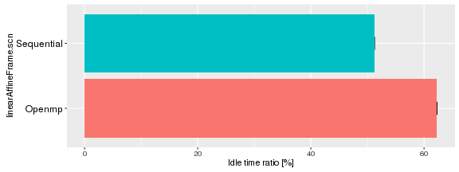

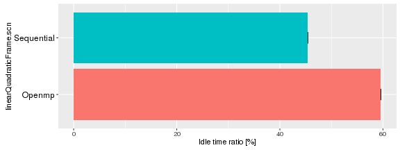

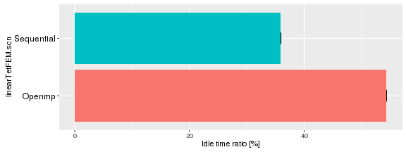

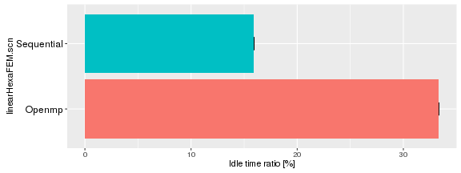

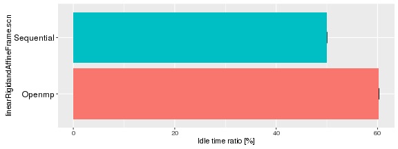

```r
for(sn in SceneNumbers)
{
  # show(plots[[sn]][[group]][[grep("Idle",
  #                              plotTitles[[sn]][[group]])]][[1]])
   show(plots[[sn]][[group]][[grep("Idle",
                                plotTitles[[sn]][[group]])]][[3]])
}
```

15 a 50% de temps perdu en séquentiel, 35-60 en parallèle, mais tous les threads ne sont pas toujours utilisés (seulement quelques zones parallèles).Attention fiabilité de la métrique

### Runtime ratio

Cette métrique est dérivée des Runtime RDTSC globale et par fonction, elle montre le ratio de temps passé dans chaque fonction observée.

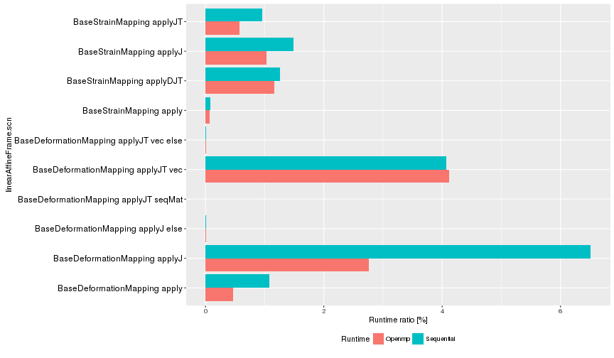

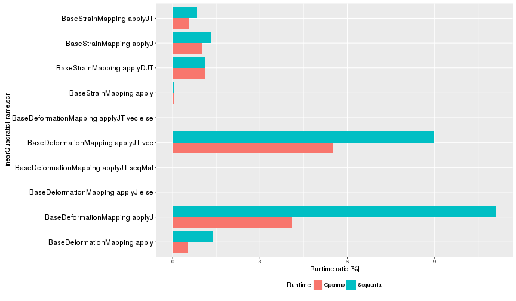

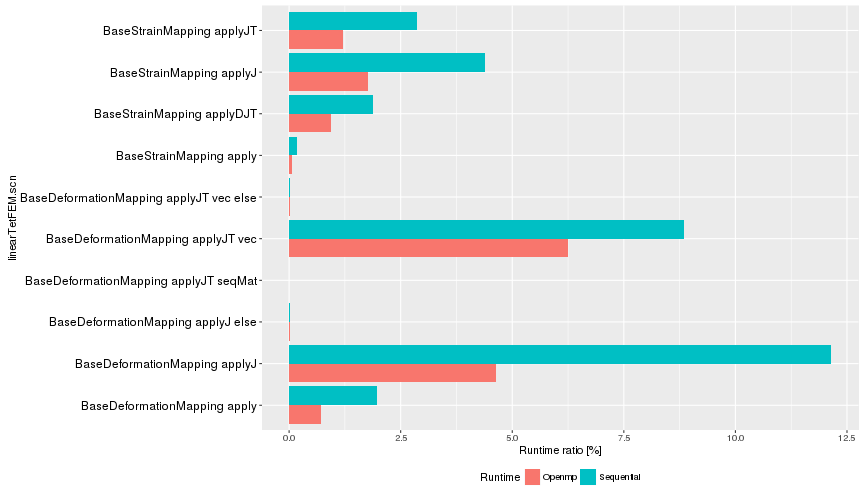

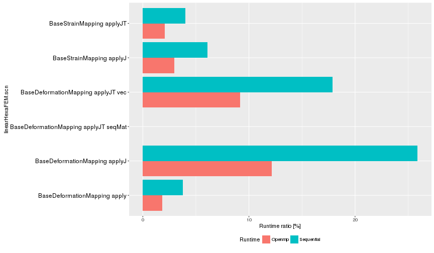

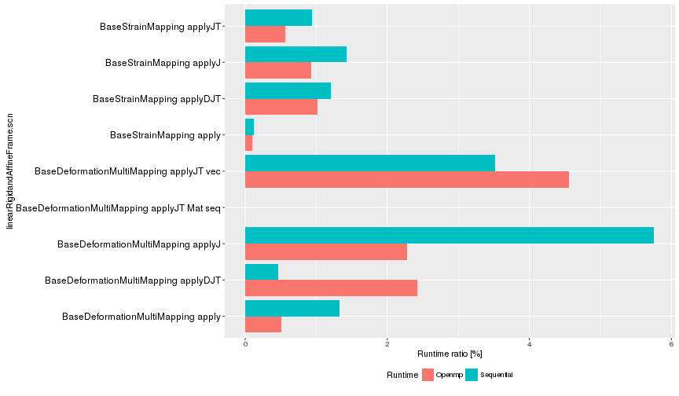

```r
group<-1
for(sn in SceneNumbers)
{
   #show(plots[[sn]][[group]][[grep("Idle",
   #                             plotTitles[[sn]][[group]])]][[2]])
   #show(plots[[sn]][[group]][[grep("unhalted",
   #                             plotTitles[[sn]][[group]])]][[2]])
   #show(plots[[sn]][[group]][[grep("RDTSC",
   #                             plotTitles[[sn]][[group]])]][[1]])
   #show(plots[[sn]][[group]][[grep("RDTSC",
   #                             plotTitles[[sn]][[group]])]][[2]])
   show(plots[[sn]][[group]][[grep("Runtime ratio",
                                plotTitles[[sn]][[group]])]][[2]])
}
```

ApplyJ et applyJT vec ressortent, cependant la majorité du temps de simu n'est pas capturé ici …

### Temps de simulation

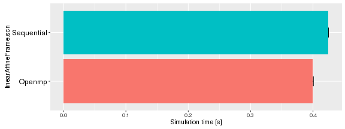

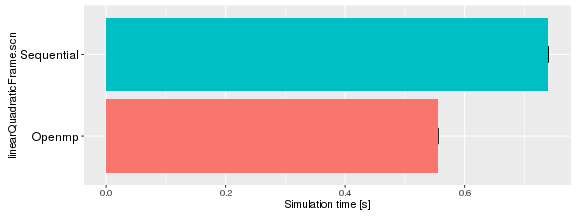

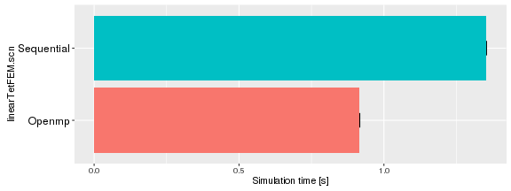

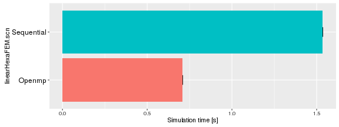

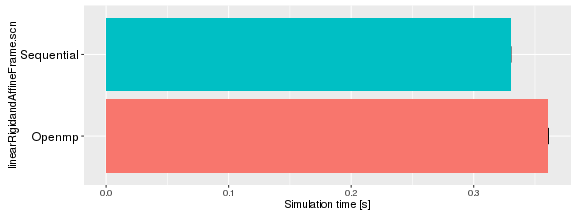

```r
group<-1
for(sn in SceneNumbers)
{
show(plots[[sn]][[group]][[grep("Simulation",
                                plotTitles[[sn]][[group]])]][[1]])
#show(plots[[sn]][[group]][[grep("RDTSC",
#                                plotTitles[[sn]][[group]])]][[3]])
#show(plots[[sn]][[group]][[grep("FPS",
#                                plotTitles[[sn]][[group]])]][[1]])
}
```

L'utilisation d'openmp semble efficace néanmoins les gains sont inégaux selon les scènes, et négatif pour la scène “linearRigidAffineFrame”.

## Groupes Likwid

### Groupes mesurés

Les courbes suivantes présentent les résultat de métriques extraites des groupes likwid. Leurs descriptions peuvent être obtenues par la commande :

```
likwid-perfct -H -g <group>
```

1. L2

   Pour Les métriques des deux prochains groupes, nous utilisons la somme sur les cœurs pour les exécutions parallèles, car chaque cœur mesure uniquement des défauts de caches.

   > Formulas:

   > L2 Load [MBytes/s] = 1.0E-06*L1D_REPLACEMENT*64/time

   > L2 Evict [MBytes/s] = 1.0E-06*L1D_M_EVICT*64/time

   > **L2 bandwidth [MBytes/s] = 1.0E-06*64*(L1D_REPLACEMENT+L1D_M_EVICT)/time**

   > **L2 data volume [GBytes] = 1.0E-09*64*(L1D_REPLACEMENT+L1D_M_EVICT)**

   > Profiling group to measure L2 cache bandwidth. The bandwidth is computed by the number of cacheline allocated in the L1 and the number of modified cachelines evicted from the L1. The group also output total data volume transfered between L2 and L1. Note that this bandwidth also includes data transfers due to a write allocate load on a store miss in L1.
2. L3

   > Formulas:

   > L3 Load [MBytes/s] 1.0E-06*L2_LINES_IN_ALL*64/time

   > L3 Evict [MBytes/s] 1.0E-06*L2_LINES_OUT_DIRTY_ALL*64/time

   > **L3 bandwidth [MBytes/s] 1.0E-06*(L2_LINES_IN_ALL+L2_LINES_OUT_DIRTY_ALL)*64/time**

   > **L3 data volume [GBytes] 1.0E-09*(L2_LINES_IN_ALL+L2_LINES_OUT_DIRTY_ALL)*64**

   > Formulas:

   > L2 request rate = L2_TRANS_ALL_REQUESTS / INSTR_RETIRED_ANY

   > L2 miss rate = L2_RQSTS_MISS / INSTR_RETIRED_ANY

   > **L2 miss ratio = L2_RQSTS_MISS / L2_TRANS_ALL_REQUESTS**

   > This group measures the locality of your data accesses with regard to the L2 Cache. L2 request rate tells you how data intensive your code is or how many Data accesses you have in average per instruction. The L2 miss rate gives a measure how often it was necessary to get cachelines from memory. And finally L2 miss ratio tells you how many of your memory references required a cacheline to be loaded from a higher level. While the Data cache miss rate might be given by your algorithm you should try to get Data cache miss ratio as low as possible by increasing your cache reuse. Note: This group might need to be revised!

   > Group MEM:

   > Profiling group to measure main memory bandwidth drawn by all cores of a socket. Since this group is based on uncore events it is only possible to measure on the granularity of a socket. If a thread group contains multiple threads only one thread per socket will show the results. Also outputs total data volume transfered from main memory.

   Metrics:

   > Memory Read BW [MBytes/s]  
   > Memory Write BW [MBytes/s]  
   > **Memory BW [MBytes/s]**  
   > **Memory data volume [GBytes]**

   Pour toutes les métriques de ce groupe, nous utilisons une somme car likwid ne les mesures que pour 1 cœur par socket, et la machine utilisée n'en contient qu'une.

Code pour afficher un groupe complet :

````
```r
#group<-grep("GROUP",groupNames)
#for(mtr in 1:4)
#{
#   for(sn in SceneNumbers)
#   {
#       show(plots[[sn]][[group]][[mtr]][[1]])
#       show(plots[[sn]][[group]][[mtr]][[2]])
#   }
#}
```
````

### Résultats d'analyse

Pour plus de lisibilité on se restreint a quelques métriques (celle précédemment mise en gras).

#### Trafic mémoire

Analysons le trafic mémoire entre le depuis le cache L1 jusqu'à la RAM.

- Par fonctions

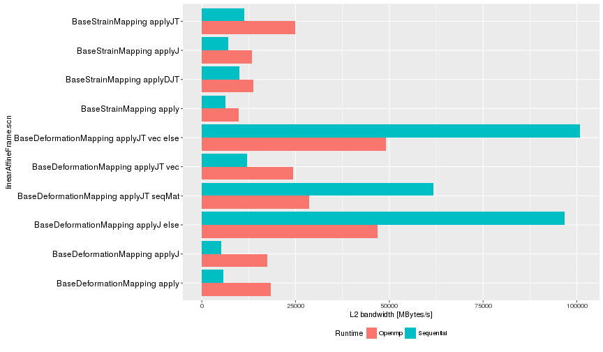

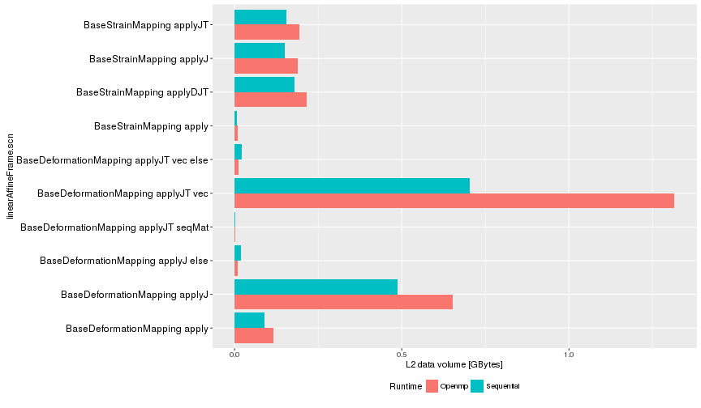

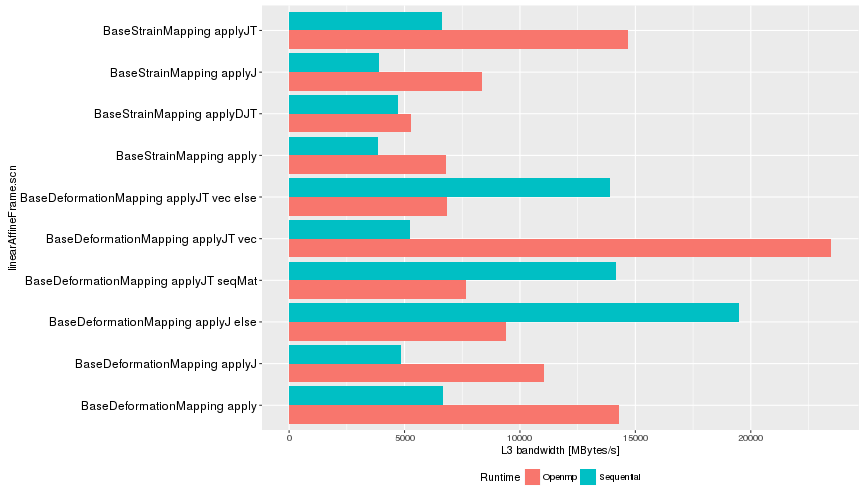

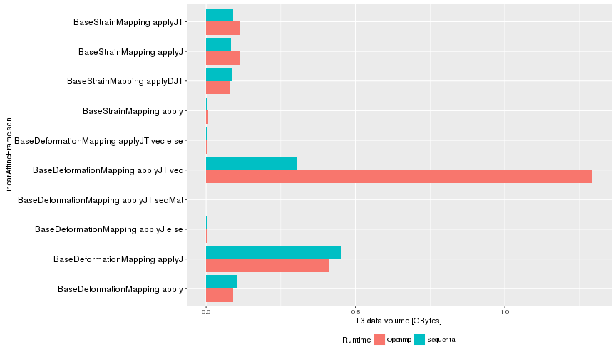

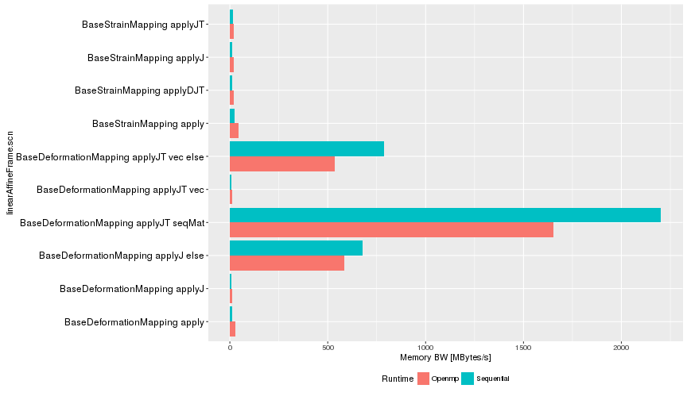

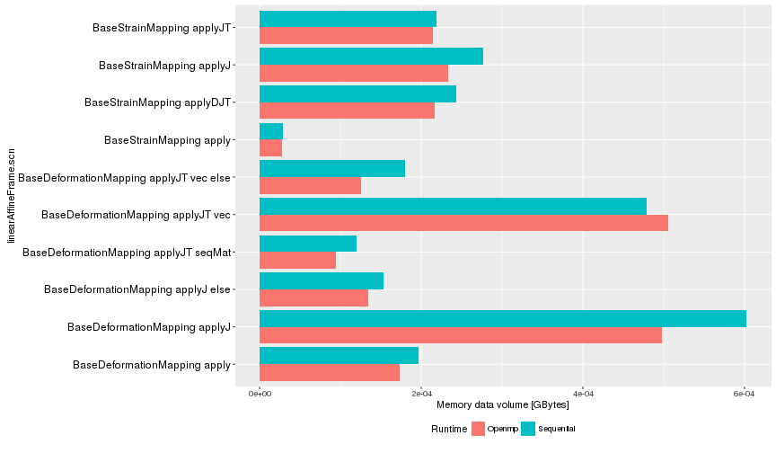

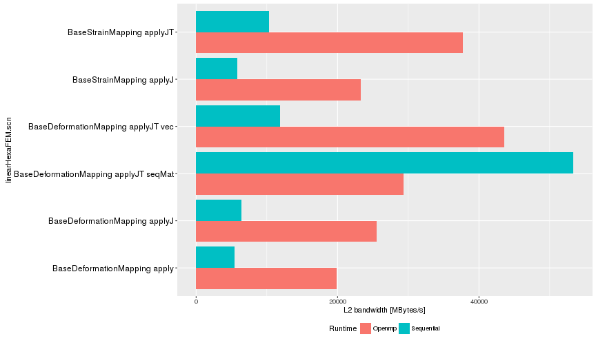

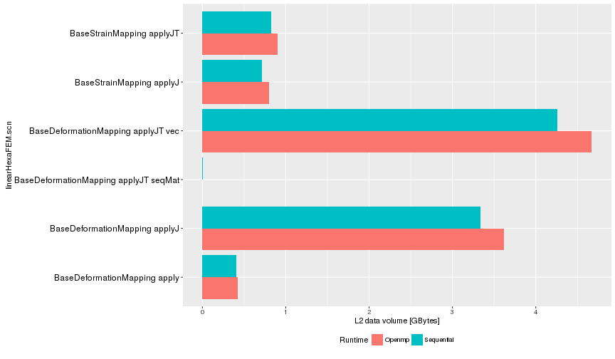

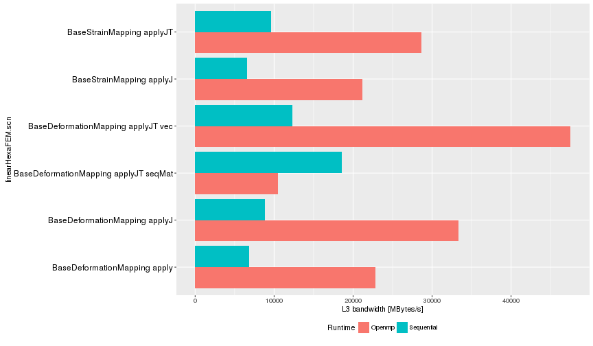

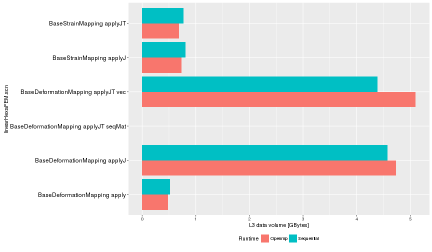

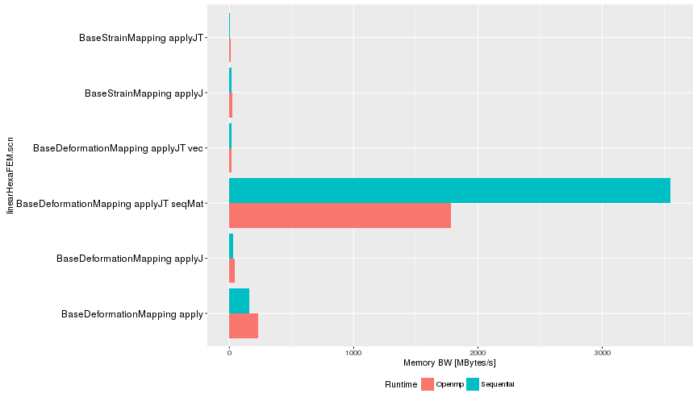

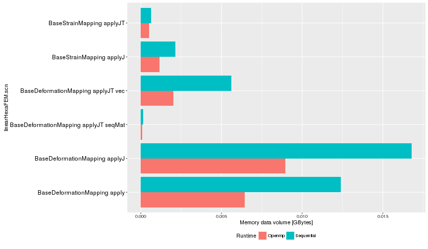

[12 more figures not shown]

  ```r
  SceneNumbers  <-  c(1,2,3,4)
  for(sn in SceneNumbers)
  {
      group<-grep("L2$",groupNames)
      mtr<-grep("bandwidth",plotTitles[[sn]][[group]])
      show(plots[[sn]][[group]][[mtr]][[2]])
      mtr<-grep("data volume",plotTitles[[sn]][[group]])
      show(plots[[sn]][[group]][[mtr]][[2]])
      group<-grep("L3",groupNames)
      mtr<-grep("bandwidth",plotTitles[[sn]][[group]])
      show(plots[[sn]][[group]][[mtr]][[2]])
      mtr<-grep("data volume",plotTitles[[sn]][[group]])
      show(plots[[sn]][[group]][[mtr]][[2]])
      group<-grep("MEM",groupNames)
      mtr<-grep("Memory BW",plotTitles[[sn]][[group]])
      show(plots[[sn]][[group]][[mtr]][[2]])
      mtr<-grep("data volume",plotTitles[[sn]][[group]])
      show(plots[[sn]][[group]][[mtr]][[2]])
  }
  ```

- Au global

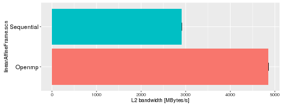

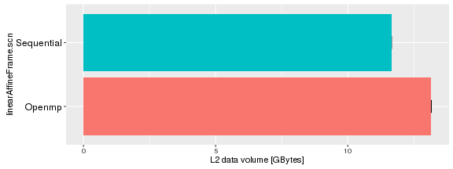

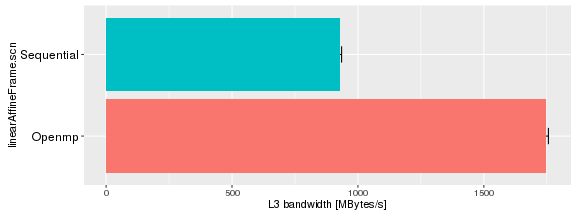

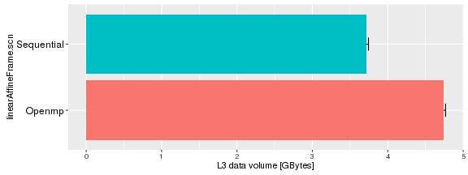

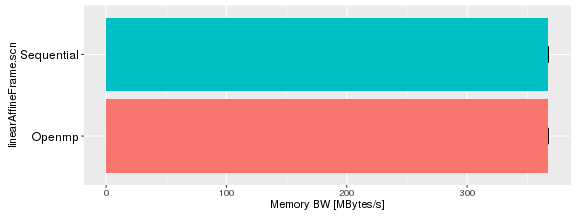

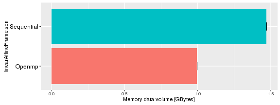

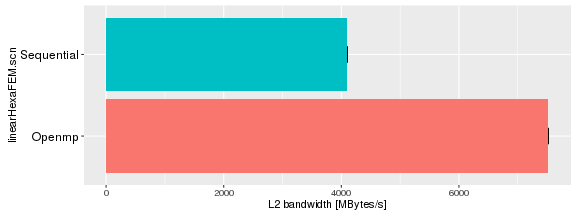

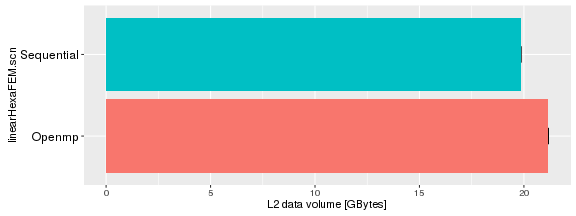

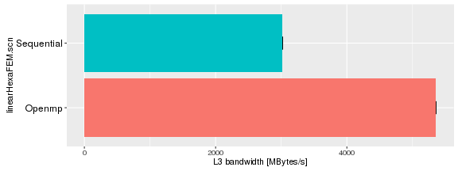

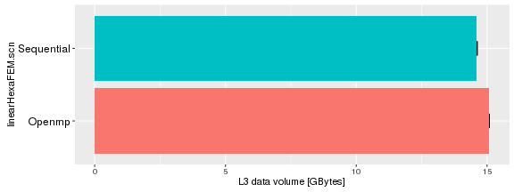

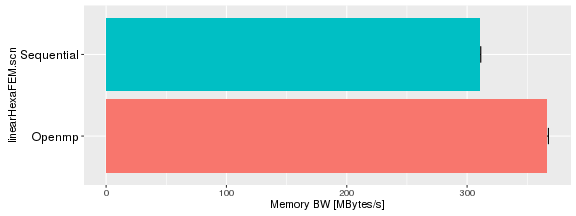

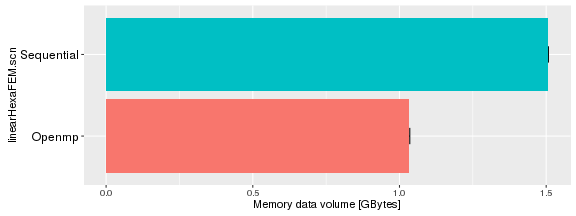

[12 more figures not shown]

  ```r
  for(sn in SceneNumbers)
  {
      group<-grep("L2$",groupNames)
      mtr<-grep("bandwidth",plotTitles[[sn]][[group]])
      show(plots[[sn]][[group]][[mtr]][[1]])
      mtr<-grep("data volume",plotTitles[[sn]][[group]])
      show(plots[[sn]][[group]][[mtr]][[1]])
      group<-grep("L3",groupNames)
      mtr<-grep("bandwidth",plotTitles[[sn]][[group]])
      show(plots[[sn]][[group]][[mtr]][[1]])
      mtr<-grep("data volume",plotTitles[[sn]][[group]])
      show(plots[[sn]][[group]][[mtr]][[1]])
      group<-grep("MEM",groupNames)
      mtr<-grep("Memory BW",plotTitles[[sn]][[group]])
      show(plots[[sn]][[group]][[mtr]][[1]])
      mtr<-grep("data volume",plotTitles[[sn]][[group]])
      show(plots[[sn]][[group]][[mtr]][[1]])
  }
  ```

- Au niveau de la simulation

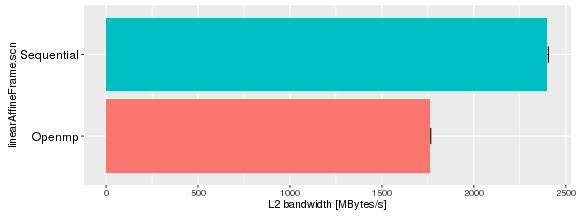

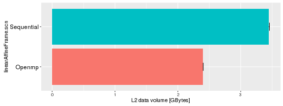

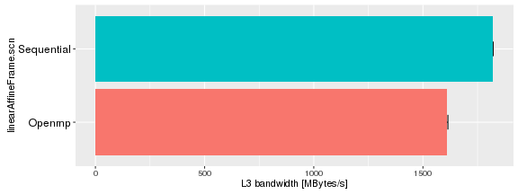

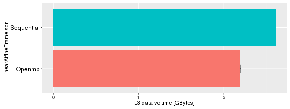

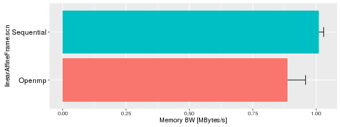

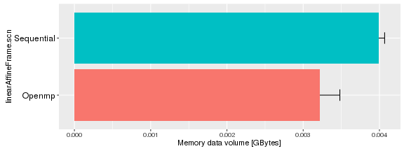

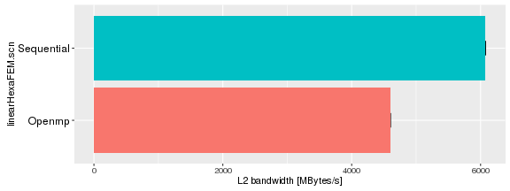

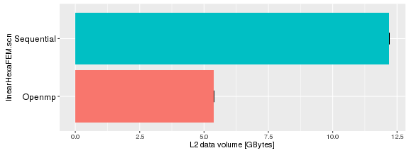

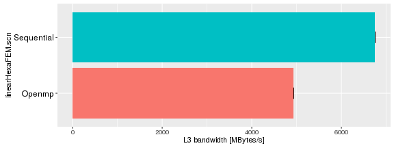

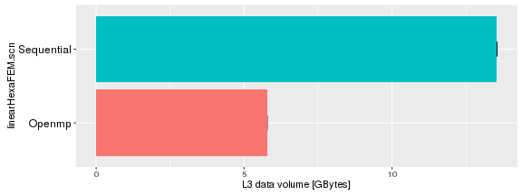

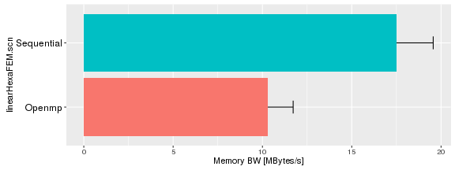

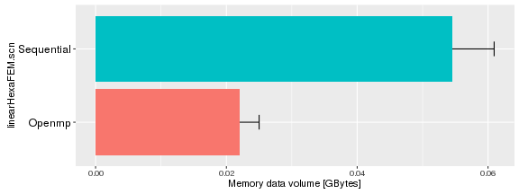

[12 more figures not shown]

  ```r
  for(sn in SceneNumbers)
  {
      group<-grep("L2$",groupNames)
      mtr<-grep("bandwidth",plotTitles[[sn]][[group]])
      show(plots[[sn]][[group]][[mtr]][[3]])
      mtr<-grep("data volume",plotTitles[[sn]][[group]])
      show(plots[[sn]][[group]][[mtr]][[3]])
      group<-grep("L3",groupNames)
      mtr<-grep("bandwidth",plotTitles[[sn]][[group]])
      show(plots[[sn]][[group]][[mtr]][[3]])
      mtr<-grep("data volume",plotTitles[[sn]][[group]])
      show(plots[[sn]][[group]][[mtr]][[3]])
      group<-grep("MEM",groupNames)
      mtr<-grep("Memory BW",plotTitles[[sn]][[group]])
      show(plots[[sn]][[group]][[mtr]][[3]])
      mtr<-grep("data volume",plotTitles[[sn]][[group]])
      show(plots[[sn]][[group]][[mtr]][[3]])
  }
  ```

  Au global l'utilisation mémoire s'intensifie en parallèle, mais pas si l'on se restreint à la partie simulation.

```r
#Clean the environment
remove(sn)
remove(scnNum)
remove(grpNum)
remove(mtr)
remove(plots)
remove(nplots)
remove(plotTitles)
remove(group)
remove(p)
remove(SceneNumbers)
remove(groupNames)
remove(resgrep)
remove(MyPlotter)
remove(resgrep1)
remove(val)
remove(i)
```

## Conclusions

- Comme prévu des fonctions clés ressortent (applyJ et applyJT de BaseDeformationMapping).
- La parallélisation openmp est déjà rentable mais elle semble limitée par la mémoire.
- Des problèmes mémoire sur la zone applyJT vec
- Potentiellement des choses à voir côté initialisation

Il faudrait observer la forme des accès mémoire, essayer de déclencher plus de partage entre les threads en parallélisant à un niveau plus global ?